# SLF_Project_LearnerNotebook_FullCode_Stefhany

## Problem Statement

#### Stefhany Rodriguez / Project 3

### Business Context

Buying and selling used phones and tablets used to be something that happened on a handful of online marketplace sites. But the used and refurbished device market has grown considerably over the past decade, and a new IDC (International Data Corporation) forecast predicts that the used phone market would be worth \$52.7bn by 2023 with a compound annual growth rate (CAGR) of 13.6% from 2018 to 2023. This growth can be attributed to an uptick in demand for used phones and tablets that offer considerable savings compared with new models.

Refurbished and used devices continue to provide cost-effective alternatives to both consumers and businesses that are looking to save money when purchasing one. There are plenty of other benefits associated with the used device market. Used and refurbished devices can be sold with warranties and can also be insured with proof of purchase. Third-party vendors/platforms, such as Verizon, Amazon, etc., provide attractive offers to customers for refurbished devices. Maximizing the longevity of devices through second-hand trade also reduces their environmental impact and helps in recycling and reducing waste. The impact of the COVID-19 outbreak may further boost this segment as consumers cut back on discretionary spending and buy phones and tablets only for immediate needs.

### Objective

The rising potential of this comparatively under-the-radar market fuels the need for an ML-based solution to develop a dynamic pricing strategy for used and refurbished devices. ReCell, a startup aiming to tap the potential in this market, has hired you as a data scientist. They want you to analyze the data provided and build a linear regression model to predict the price of a used phone/tablet and identify factors that significantly influence it.

### Data Description

The data contains the different attributes of used/refurbished phones and tablets. The data was collected in the year 2021. The detailed data dictionary is given below.

- brand_name: Name of manufacturing brand
- os: OS on which the device runs
- screen_size: Size of the screen in cm
- 4g: Whether 4G is available or not
- 5g: Whether 5G is available or not
- main_camera_mp: Resolution of the rear camera in megapixels
- selfie_camera_mp: Resolution of the front camera in megapixels
- int_memory: Amount of internal memory (ROM) in GB
- ram: Amount of RAM in GB
- battery: Energy capacity of the device battery in mAh
- weight: Weight of the device in grams
- release_year: Year when the device model was released
- days_used: Number of days the used/refurbished device has been used
- normalized_new_price: Normalized price of a new device of the same model in euros
- normalized_used_price: Normalized price of the used/refurbished device in euros

## Importing necessary libraries

```python
# Installing the libraries with the specified version.
# uncomment and run the following line if Google Colab is being used
# !pip install scikit-learn==1.2.2 seaborn==0.13.1 matplotlib==3.7.1 numpy==1.25.2 pandas==1.5.3 -q --user
```

```python
# Installing the libraries with the specified version.
# uncomment and run the following lines if Jupyter Notebook is being used
#!pip install scikit-learn==1.2.2 seaborn==0.11.1 matplotlib==3.3.4 numpy==1.24.3 pandas==1.5.2 -q --user
```

**Note**: *After running the above cell, kindly restart the notebook kernel and run all cells sequentially from the start again.*

```python
import pandas as pd
import numpy as np

# for visualizing data
import matplotlib.pyplot as plt
import seaborn as sns

# For randomized data splitting
from sklearn.model_selection import train_test_split

# To build linear regression_model
import statsmodels.api as sm

# To check model performance
from sklearn.metrics import mean_absolute_error, mean_squared_error, r2_score
from statsmodels.stats.outliers_influence import variance_inflation_factor
```

## Loading the dataset

```python
#Reading the data from the folder of my posgraduate program module supervised learning
data = pd.read_csv("/Users/stefhanyrodriguez/Documents/Supervised learning/Project3/used_device_data.csv")
```

## Data Overview

- Observations
- Sanity checks

```python
# Displaying the first 5 rows
data.head()
```

|  | brand_name | os | screen_size | 4g | 5g | main_camera_mp | selfie_camera_mp | int_memory | ram | battery | weight | release_year | days_used | normalized_used_price | normalized_new_price |
| --- | --- | --- | --- | --- | --- | --- | --- | --- | --- | --- | --- | --- | --- | --- | --- |
| 0 | Honor | Android | 14.50 | yes | no | 13.0 | 5.0 | 64.0 | 3.0 | 3020.0 | 146.0 | 2020 | 127 | 4.307572 | 4.715100 |
| 1 | Honor | Android | 17.30 | yes | yes | 13.0 | 16.0 | 128.0 | 8.0 | 4300.0 | 213.0 | 2020 | 325 | 5.162097 | 5.519018 |
| 2 | Honor | Android | 16.69 | yes | yes | 13.0 | 8.0 | 128.0 | 8.0 | 4200.0 | 213.0 | 2020 | 162 | 5.111084 | 5.884631 |
| 3 | Honor | Android | 25.50 | yes | yes | 13.0 | 8.0 | 64.0 | 6.0 | 7250.0 | 480.0 | 2020 | 345 | 5.135387 | 5.630961 |
| 4 | Honor | Android | 15.32 | yes | no | 13.0 | 8.0 | 64.0 | 3.0 | 5000.0 | 185.0 | 2020 | 293 | 4.389995 | 4.947837 |

```python
# Displaying the last 5 rows
data.tail()
```

|  | brand_name | os | screen_size | 4g | 5g | main_camera_mp | selfie_camera_mp | int_memory | ram | battery | weight | release_year | days_used | normalized_used_price | normalized_new_price |
| --- | --- | --- | --- | --- | --- | --- | --- | --- | --- | --- | --- | --- | --- | --- | --- |
| 3449 | Asus | Android | 15.34 | yes | no | NaN | 8.0 | 64.0 | 6.0 | 5000.0 | 190.0 | 2019 | 232 | 4.492337 | 6.483872 |
| 3450 | Asus | Android | 15.24 | yes | no | 13.0 | 8.0 | 128.0 | 8.0 | 4000.0 | 200.0 | 2018 | 541 | 5.037732 | 6.251538 |
| 3451 | Alcatel | Android | 15.80 | yes | no | 13.0 | 5.0 | 32.0 | 3.0 | 4000.0 | 165.0 | 2020 | 201 | 4.357350 | 4.528829 |
| 3452 | Alcatel | Android | 15.80 | yes | no | 13.0 | 5.0 | 32.0 | 2.0 | 4000.0 | 160.0 | 2020 | 149 | 4.349762 | 4.624188 |
| 3453 | Alcatel | Android | 12.83 | yes | no | 13.0 | 5.0 | 16.0 | 2.0 | 4000.0 | 168.0 | 2020 | 176 | 4.132122 | 4.279994 |

```python
#shape returns a tuple with the number of rows and columns
rows, columns = data.shape
print('The dataset has', rows, 'rows.')
print('The dataset has', columns, 'columns.')
```

```
The dataset has 3454 rows.
The dataset has 15 columns.
```

```python
#.describe() gives a summary statistical for a numerical column by default
data.describe()
```

|  | screen_size | main_camera_mp | selfie_camera_mp | int_memory | ram | battery | weight | release_year | days_used | normalized_used_price | normalized_new_price |
| --- | --- | --- | --- | --- | --- | --- | --- | --- | --- | --- | --- |
| count | 3454.000000 | 3275.000000 | 3452.000000 | 3450.000000 | 3450.000000 | 3448.000000 | 3447.000000 | 3454.000000 | 3454.000000 | 3454.000000 | 3454.000000 |
| mean | 13.713115 | 9.460208 | 6.554229 | 54.573099 | 4.036122 | 3133.402697 | 182.751871 | 2015.965258 | 674.869716 | 4.364712 | 5.233107 |
| std | 3.805280 | 4.815461 | 6.970372 | 84.972371 | 1.365105 | 1299.682844 | 88.413228 | 2.298455 | 248.580166 | 0.588914 | 0.683637 |
| min | 5.080000 | 0.080000 | 0.000000 | 0.010000 | 0.020000 | 500.000000 | 69.000000 | 2013.000000 | 91.000000 | 1.536867 | 2.901422 |
| 25% | 12.700000 | 5.000000 | 2.000000 | 16.000000 | 4.000000 | 2100.000000 | 142.000000 | 2014.000000 | 533.500000 | 4.033931 | 4.790342 |
| 50% | 12.830000 | 8.000000 | 5.000000 | 32.000000 | 4.000000 | 3000.000000 | 160.000000 | 2015.500000 | 690.500000 | 4.405133 | 5.245892 |
| 75% | 15.340000 | 13.000000 | 8.000000 | 64.000000 | 4.000000 | 4000.000000 | 185.000000 | 2018.000000 | 868.750000 | 4.755700 | 5.673718 |
| max | 30.710000 | 48.000000 | 32.000000 | 1024.000000 | 12.000000 | 9720.000000 | 855.000000 | 2020.000000 | 1094.000000 | 6.619433 | 7.847841 |

- Count, mean, std, min, 25%, 50%, 75%, max are provided for numerical variables.

```python
data.describe(include='all')
```

|  | brand_name | os | screen_size | 4g | 5g | main_camera_mp | selfie_camera_mp | int_memory | ram | battery | weight | release_year | days_used | normalized_used_price | normalized_new_price |
| --- | --- | --- | --- | --- | --- | --- | --- | --- | --- | --- | --- | --- | --- | --- | --- |
| count | 3454 | 3454 | 3454.000000 | 3454 | 3454 | 3275.000000 | 3452.000000 | 3450.000000 | 3450.000000 | 3448.000000 | 3447.000000 | 3454.000000 | 3454.000000 | 3454.000000 | 3454.000000 |
| unique | 34 | 4 | NaN | 2 | 2 | NaN | NaN | NaN | NaN | NaN | NaN | NaN | NaN | NaN | NaN |
| top | Others | Android | NaN | yes | no | NaN | NaN | NaN | NaN | NaN | NaN | NaN | NaN | NaN | NaN |
| freq | 502 | 3214 | NaN | 2335 | 3302 | NaN | NaN | NaN | NaN | NaN | NaN | NaN | NaN | NaN | NaN |
| mean | NaN | NaN | 13.713115 | NaN | NaN | 9.460208 | 6.554229 | 54.573099 | 4.036122 | 3133.402697 | 182.751871 | 2015.965258 | 674.869716 | 4.364712 | 5.233107 |
| std | NaN | NaN | 3.805280 | NaN | NaN | 4.815461 | 6.970372 | 84.972371 | 1.365105 | 1299.682844 | 88.413228 | 2.298455 | 248.580166 | 0.588914 | 0.683637 |
| min | NaN | NaN | 5.080000 | NaN | NaN | 0.080000 | 0.000000 | 0.010000 | 0.020000 | 500.000000 | 69.000000 | 2013.000000 | 91.000000 | 1.536867 | 2.901422 |
| 25% | NaN | NaN | 12.700000 | NaN | NaN | 5.000000 | 2.000000 | 16.000000 | 4.000000 | 2100.000000 | 142.000000 | 2014.000000 | 533.500000 | 4.033931 | 4.790342 |
| 50% | NaN | NaN | 12.830000 | NaN | NaN | 8.000000 | 5.000000 | 32.000000 | 4.000000 | 3000.000000 | 160.000000 | 2015.500000 | 690.500000 | 4.405133 | 5.245892 |
| 75% | NaN | NaN | 15.340000 | NaN | NaN | 13.000000 | 8.000000 | 64.000000 | 4.000000 | 4000.000000 | 185.000000 | 2018.000000 | 868.750000 | 4.755700 | 5.673718 |
| max | NaN | NaN | 30.710000 | NaN | NaN | 48.000000 | 32.000000 | 1024.000000 | 12.000000 | 9720.000000 | 855.000000 | 2020.000000 | 1094.000000 | 6.619433 | 7.847841 |

- brand_name, os, 4g, 5g are categorical variables hence for this type of variables pandas calculates: count, unique, top and freq.
- Seeing NaN values for categorical columns in the output of .describe() is expected and indicates that those specific statistics are not applicable to categorical.

### Data types of the columns for the dataset

```python
#dtypes is used to see data types of each column
data_types_column = data.dtypes
print(data_types_column)
```

```
brand_name                object
os                        object
screen_size              float64
4g                        object
5g                        object
main_camera_mp           float64
selfie_camera_mp         float64
int_memory               float64
ram                      float64
battery                  float64
weight                   float64
release_year               int64
days_used                  int64
normalized_used_price    float64
normalized_new_price     float64
dtype: object
```

- Here I can evidence the 3 different data types of the columns in the data frame: object, float and int.
- brand, os, 4g, 5g are objects, used to represent string type.
- screen_size, main_camera_mp, selfie_camera_mp, int_memory, ram, battery, weight, normalized_used_price, normalized_new_price are float type.
- release_year and days_used are integer.

### Missing values

```python
#Checking for missing values
missing_values = data.isnull().sum()
print(missing_values)
print('')
it_has_missing_values = data.isnull().sum().any()
print("Are there any missing values: true or false?", it_has_missing_values)
```

```
brand_name                 0
os                         0
screen_size                0
4g                         0
5g                         0
main_camera_mp           179
selfie_camera_mp           2
int_memory                 4
ram                        4
battery                    6
weight                     7
release_year               0
days_used                  0
normalized_used_price      0
normalized_new_price       0
dtype: int64

Are there any missing values: true or false? True
```

- Here I can evidence that there are 6 data types which contains missing values: main camera mp with 179 missing values, selfie camera mp with 2 missing values, int memory 4 missing, ram 4 missing values, battery 6 missing values and weight 7 missing values.

### Duplicates

```python
# Check if there's any duplicates
duplicates= data.duplicated()
duplicates.sum()
```

```
0
```

- There's no duplicates in the dataframe.

```python
# creating a copy of the data so that original data remains unchanged
df = data.copy()
```

## Exploratory Data Analysis (EDA)

- EDA is an important part of any project involving data.
- It is important to investigate and understand the data better before building a model with it.
- A few questions have been mentioned below which will help you approach the analysis in the right manner and generate insights from the data.
- A thorough analysis of the data, in addition to the questions mentioned below, should be done.

**Questions**:

1. What does the distribution of normalized used device prices look like?
2. What percentage of the used device market is dominated by Android devices?
3. The amount of RAM is important for the smooth functioning of a device. How does the amount of RAM vary with the brand?
4. A large battery often increases a device's weight, making it feel uncomfortable in the hands. How does the weight vary for phones and tablets offering large batteries (more than 4500 mAh)?
5. Bigger screens are desirable for entertainment purposes as they offer a better viewing experience. How many phones and tablets are available across different brands with a screen size larger than 6 inches?
6. A lot of devices nowadays offer great selfie cameras, allowing us to capture our favorite moments with loved ones. What is the distribution of devices offering greater than 8MP selfie cameras across brands?
7. Which attributes are highly correlated with the normalized price of a used device?

## In the following graphs it will be found the univariate analysis to understand the distribution of the data

#### 1. Screen size

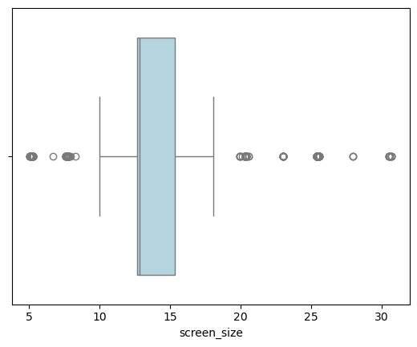

```python
sns.boxplot(data=df, x='screen_size', color= 'lightblue')
plt.show()
```

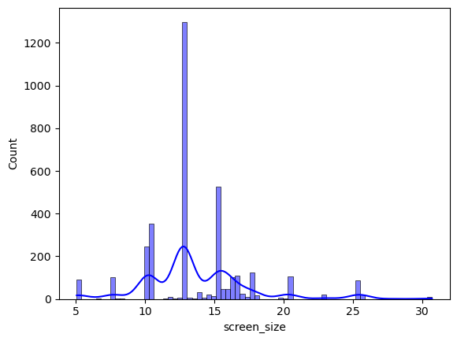

```python
sns.histplot(data=df, x='screen_size', kde=True, color='blue')
plt.show()
```

- The boxplot visualizes the distribution of the screensize, the median value is around 13 and I can evidence that the distribution is skewed to the right or positively skewed.
- The data is not symmetrically distributed.
- Regarding the Interquartile range(IQR) it varies from 12-13 to 16
- The whiskers extend to 10 and approximately 18
- There are several data points outside the whiskers representing outliers. This indicates screens significantly smaller rounding about 5 to 8 and screens larger above 20 and up to 30.
- Peak frequency of the histogram is around 13 which align which the median from the boxplot. However, there's another significant around 15 and 10 suggesting that these screen sizes are more common.
- The majority of the values fall between 10 to 18.

#### 2. Main camera mp

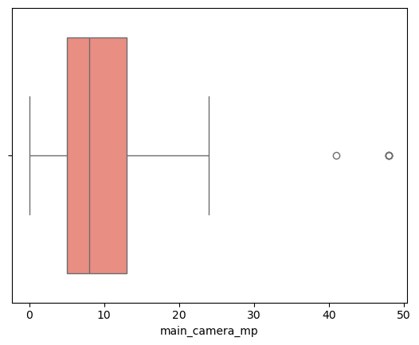

```python
sns.boxplot(data=df, x='main_camera_mp', color= 'salmon')
plt.show()
```

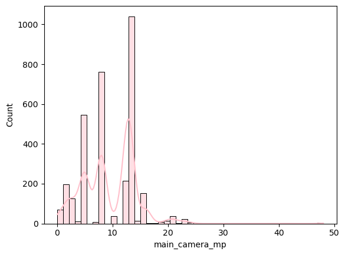

```python
sns.histplot(data=df, x='main_camera_mp', kde=True, color='pink')
plt.show()
```

- The boxplot visualizes the distribution of the main camera mp, the median value is around 8
- The distribution is slightly skewed to the right or slightly positively skewed. It indicates most smartphones have lower megapixels in their main camera, with fewer models having very high megapixels.
- The (IQR) varies from 5 to 12 aprox.
- The whiskers extend to almost 0 and approximately 23
- There are some data points outside the upper whisker representing outliers. This indicates some smartphones with significantly high megapixels for their main cameras.
- Peak frequencies around 8mp and 12mp. This can be standard megapixel configurations.
- Majority of values concentrated between 0 to 15mp.
- Outliers in 40 and 50mp.

#### 3. Selfie camera mp

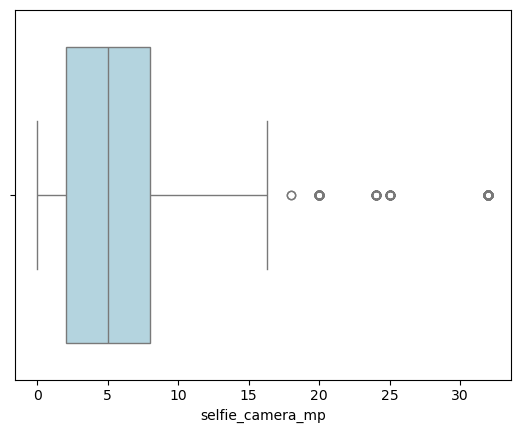

```python
sns.boxplot(data=df, x='selfie_camera_mp', color= 'lightblue')
plt.show()
```

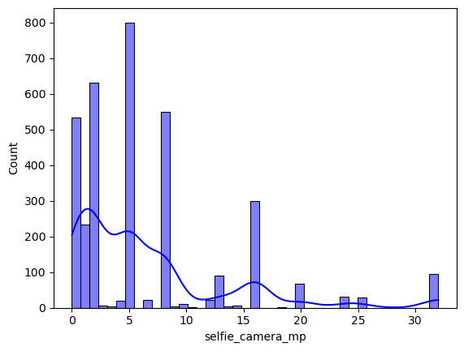

```python
sns.histplot(data=df, x='selfie_camera_mp', kde=True, color='blue')
plt.show()
```

#### 4. Int memory

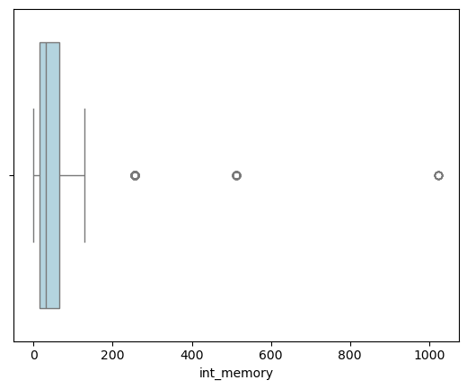

```python
sns.boxplot(data=df, x='int_memory', color= 'lightblue')
plt.show()
```

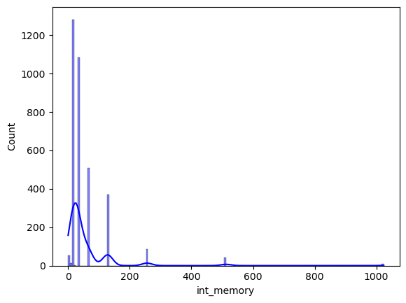

```python
sns.histplot(data=df, x='int_memory', kde=True, color='blue')
plt.show()
```

- The boxplot visualizes the distribution of the internal memory in gb, the median value is around 32.
- The distribution is skewed to the right (positively skewed). It means smaller internal memory values are more frequent.
- The (IQR) varies from 0 to 64gb aprox.
- There are some significant outliers above 512gb or even 1000gb(1Tb)
- Peak frequencies around 16, 32, 64GB.
- Most of the data varies around 0Gb to 128Gb.

#### 5. RAM

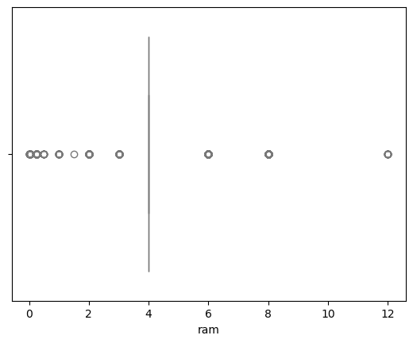

```python
sns.boxplot(data=df, x='ram', color= 'lightblue')
plt.show()
```

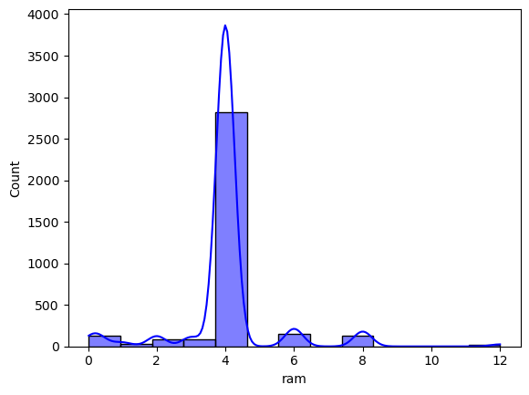

```python
sns.histplot(data=df, x='ram', kde=True, color='blue')
plt.show()
```

- The boxplot seems to be mostly concentrated in 4GB of ram.
- The histogram shows that the majority of the data points range from 0 to 4.
- The highest peak in the histogram is around 4 and seems to be the most common value in the dataset.

#### 6. Battery

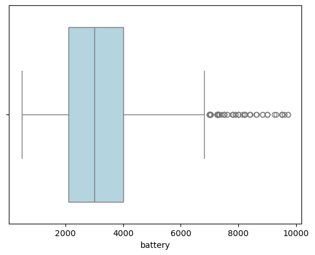

```python
sns.boxplot(data=df, x='battery', color= 'lightblue')
plt.show()
```

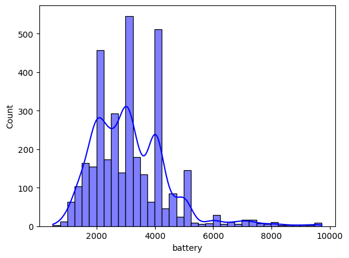

```python
sns.histplot(data=df, x='battery', kde=True, color='blue')
plt.show()
```

- The boxplot visualizes the distribution of battery, the median value is around 3000mAh
- The distribution is slightly skewed to the right or slightly positively skewed.
- The (IQR) varies from 2000 to 4000mAh.
- The upper whisker extend to above 6000 mAh.
- There are significantly data points outside the upper whisker representing outliers. This indicates some smartphones with significantly high values of battery.
- The highest peak in the histogram is aprox 3000mAh appearing to be the most frequent followed by 4000mAh and 2000mAh.
- Majority of values concentrated between 2000mAh to 6000mAh.
- There is a drop in frequency as the values increase beyond 6000mAh.

#### 7. Weight

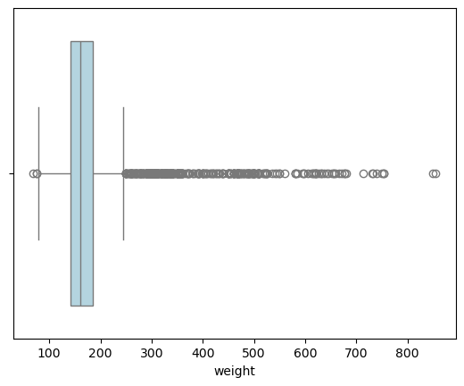

```python
sns.boxplot(data=df, x='weight', color= 'lightblue')
plt.show()
```

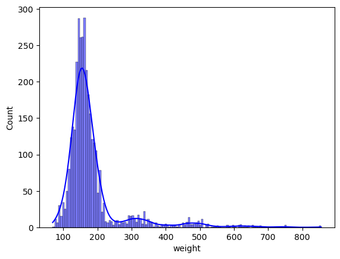

```python
sns.histplot(data=df, x='weight', kde=True, color='blue')
plt.show()
```

- The histogram shows a concentration of weights in the range 100 to 200 evidencing that this is the most common range in the data set.
- It has a right-skewed distribution with a tail extending toward higher weights.
- The KDE line indicates that most of the weights are in the lower range.
- The (IQR) varies from 120 to 180.
- The median is around 150.
- There are significantly data points outside the upper whisker representing outliers. Smartphones with higher weights are atypical.

#### 8. Days used

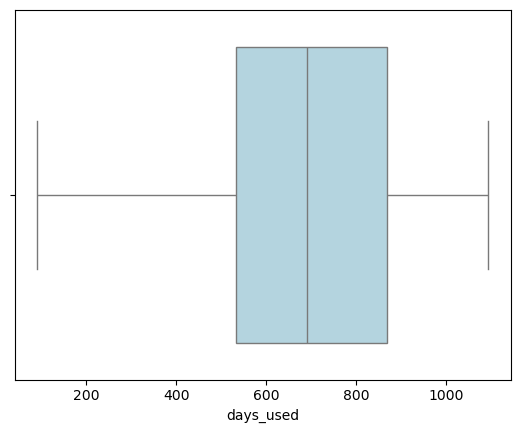

```python
sns.boxplot(data=df, x='days_used', color= 'lightblue')
plt.show()
```

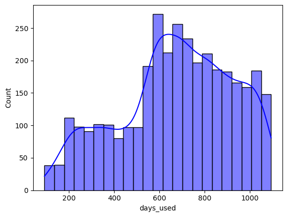

```python
sns.histplot(data=df, x='days_used', kde=True, color='blue')
plt.show()
```

#### 9. Normalized new price

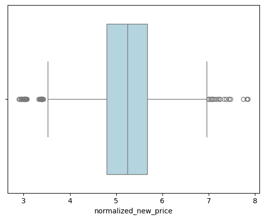

```python
sns.boxplot(data=df, x='normalized_new_price', color= 'lightblue')
plt.show()
```

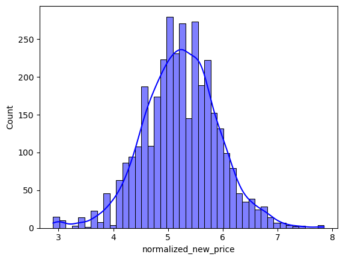

```python
sns.histplot(data=df, x='normalized_new_price', kde=True, color='blue')
plt.show()
```

- The boxplot visualizes the distribution of the normalized new price, the median value is around 5.2 aprox.
- The IQR varies from 4.8 to 5.7
- Whiskers extends to 3.5 and 7.
- There are outliers below 3.5 and above 7.
- The histogram shows a peak around 5.
- The data seems to be slightly right sweked with a tail extending beyond 6.
- The majority of the values are clustered between 4.5 to 5.8.

#### 10. Normalized used price

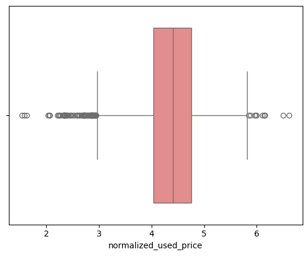

```python
sns.boxplot(data=df, x='normalized_used_price', color= 'lightcoral')
plt.show()
```

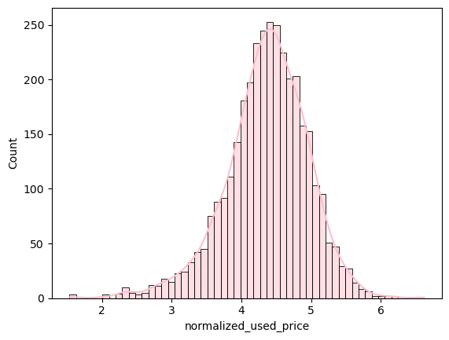

```python
sns.histplot(data=df, x='normalized_used_price', kde=True, color='Pink')
plt.show()
```

#### Brand name

[output not shown]

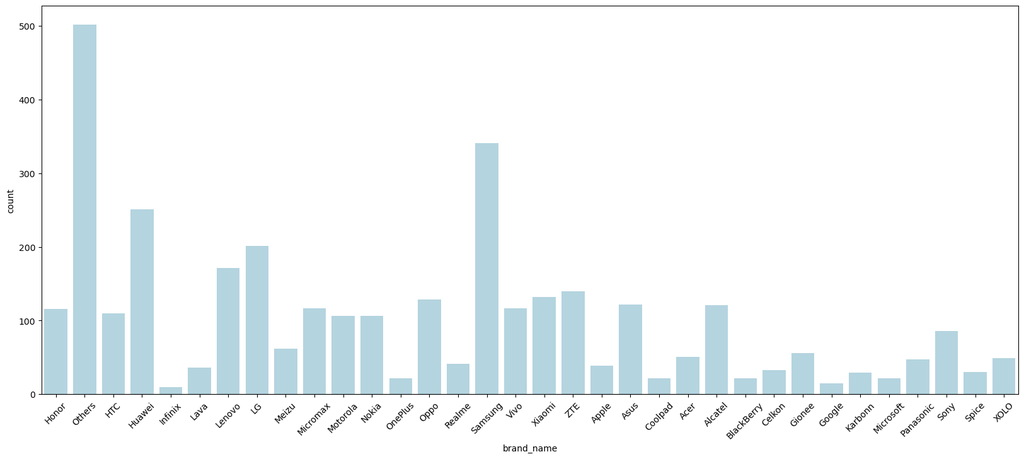

```python
plt.figure(figsize=(20,8))
sns.countplot(data=df, x='brand_name', color='lightblue')
plt.xticks(rotation=45)
```

#### OS

```
([0, 1, 2, 3],
 [Text(0, 0, 'Android'),
```

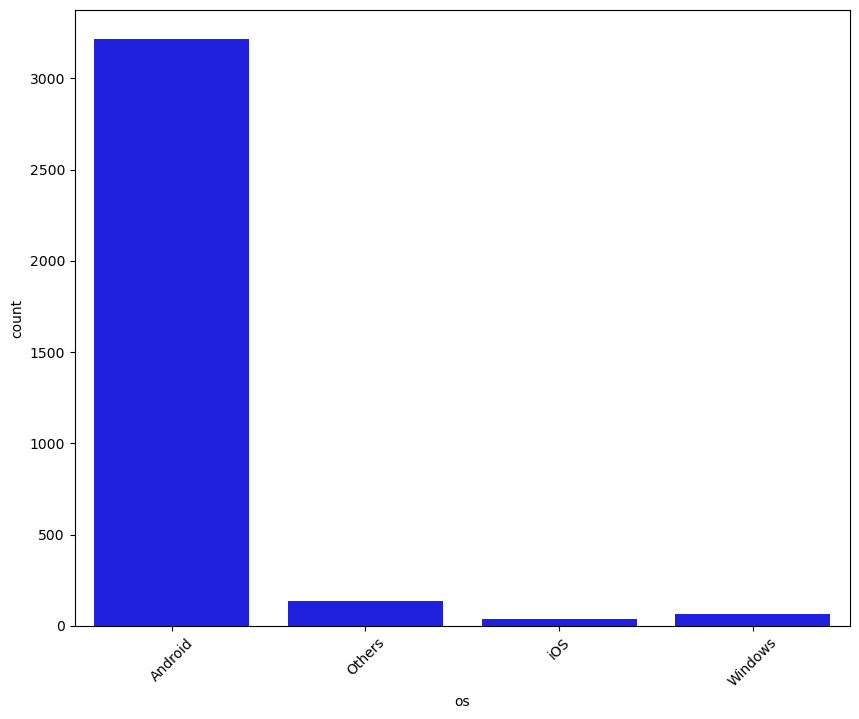

```python
plt.figure(figsize=(10,8))
sns.countplot(data=df, x='os', color='blue')
plt.xticks(rotation=45)
```

#### 4G

```
([0, 1], [Text(0, 0, 'yes'), Text(1, 0, 'no')])
```

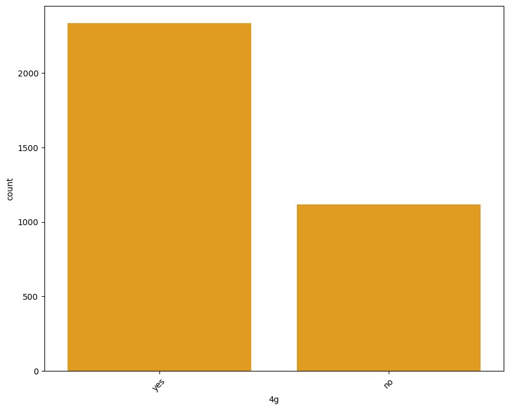

```python
plt.figure(figsize=(10,8))
sns.countplot(data=df, x='4g', color='orange')
plt.xticks(rotation=45)
```

#### 5G

```
([0, 1], [Text(0, 0, 'no'), Text(1, 0, 'yes')])
```

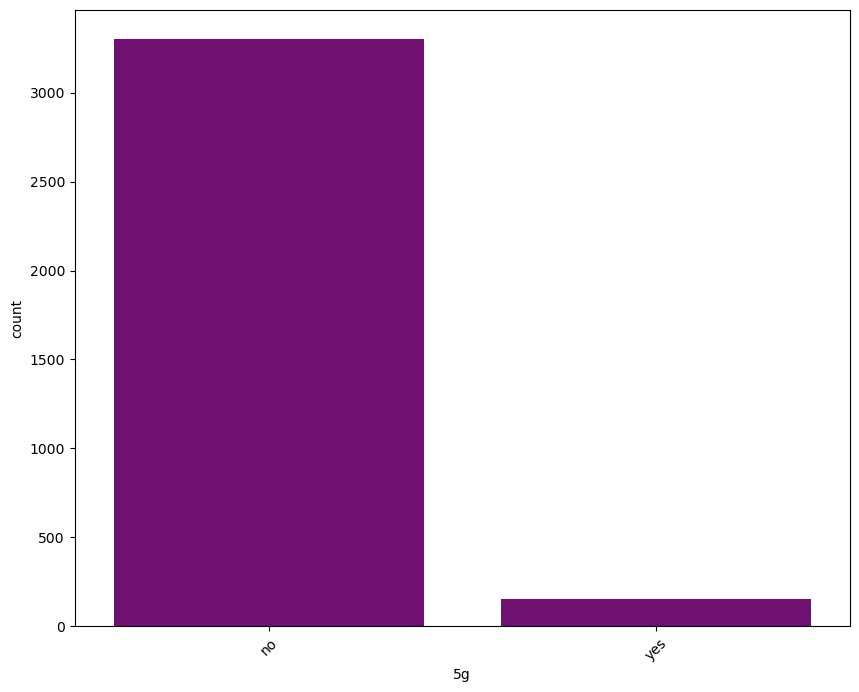

```python
plt.figure(figsize=(10,8))
sns.countplot(data=df, x='5g', color='purple')
plt.xticks(rotation=45)
```

#### Release year

```
([0, 1, 2, 3, 4, 5, 6, 7],
 [Text(0, 0, '2013'),
```

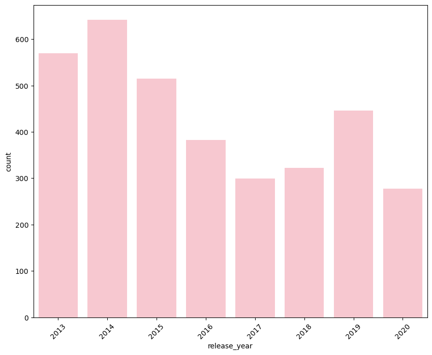

```python
plt.figure(figsize=(10,8))
sns.countplot(data=df, x='release_year', color='pink')
plt.xticks(rotation=45)
```

### The amount of RAM is important for the smooth functioning of a device. How does the amount of RAM vary with the brand?

```
brand_name    0
ram           4
dtype: int64
```

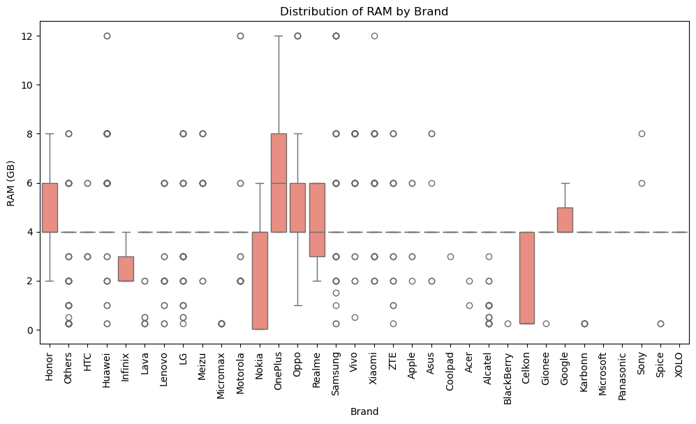

```python
# Check for any missing values in the RAM and brand columns
print(data[['brand_name', 'ram']].isnull().sum())

# Drop rows with missing values in brand_name and ram columns
df = df.dropna(subset=['brand_name', 'ram'])

# Visualize the distribution of RAM by brand using a box plot
plt.figure(figsize=(12, 6))
sns.boxplot(x='brand_name', y='ram', data=df, color='salmon')
plt.xticks(rotation=90)
plt.title('Distribution of RAM by Brand')
plt.xlabel('Brand')
plt.ylabel('RAM (GB)')
plt.show()
```

- The amount of RAM varies significantly with the brand.
- Infinix, nokia and celkon mostly stick to devices with lower RAM capacities.
- HTC, Huawei, Lava, Lenovo, LG and others seems to have mostly devices with 4GB of ram, however, there are some outliers of 2, 6, 8GB.
- Oppo and Honor seems to have devices ranging mostly from 4 to 6 GB.
- One plus brand exhibits an IQR from 4 to 8GB including higher capacities such as 10GB / 12GB

### A large battery often increases a device's weight, making it feel uncomfortable in the hands. How does the weight vary for phones and tablets offering large batteries (more than 4500 mAh)?

```
battery    5
weight     7
dtype: int64
```

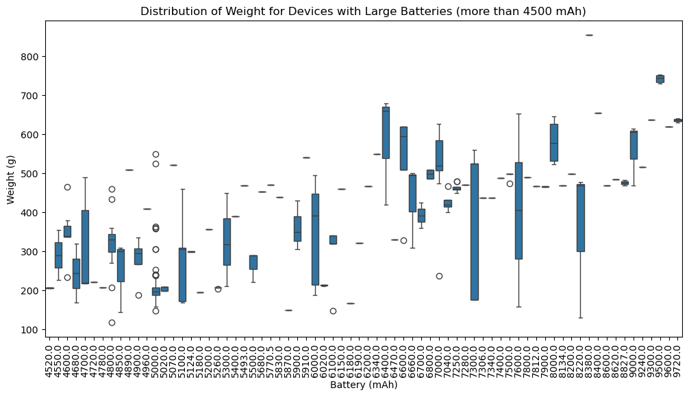

```python
# Check for any missing values in the battery and weight columns
print(df[['battery', 'weight']].isnull().sum())

# Drop rows with missing values in battery and weight columns
df = df.dropna(subset=['battery', 'weight'])

# Filter data for devices with large batteries (more than 4500 mAh)
large_battery_df = df[df['battery'] > 4500]

# Visualize the distribution of weight for devices with large batteries using a box plot
plt.figure(figsize=(12, 6))
sns.boxplot(x='battery', y='weight', data=large_battery_df)
plt.xticks(rotation=90)
plt.title('Distribution of Weight for Devices with Large Batteries (more than 4500 mAh)')
plt.xlabel('Battery (mAh)')
plt.ylabel('Weight (g)')
plt.show()
```

```python
large_battery_df.shape
```

```
(341, 15)
```

### Bigger screens are desirable for entertainment purposes as they offer a better viewing experience. How many phones and tablets are available across different brands with a screen size larger than 6 inches?

```
screen_size    0
brand_name     0
dtype: int64
   brand_name  count
0      Huawei    149
1     Samsung    119
2      Others     99
3        Vivo     80
4       Honor     72
5        Oppo     70
6      Xiaomi     69
7      Lenovo     69
8          LG     59
9    Motorola     42
10       Asus     41
```

[output cut: 19 more lines]

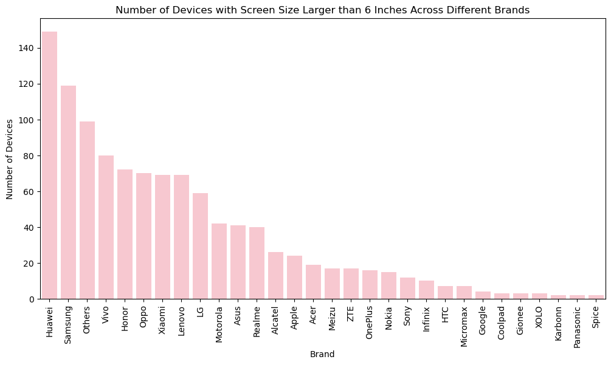

```python
# Check for any missing values in the screen_size and brand_name columns
print(df[['screen_size', 'brand_name']].isnull().sum())

# Drop rows with missing values in screen_size and brand_name columns
df = df.dropna(subset=['screen_size', 'brand_name'])

# Filter data for devices with screen size larger than 6 inches
# screen size is in cm that's why we multiply *2.54 doing the conversion
large_screen_df = df[df['screen_size'] > (6*2.54)]

# Count the number of devices per brand with large screen size
brand_screen_count = large_screen_df['brand_name'].value_counts().reset_index()
brand_screen_count.columns = ['brand_name', 'count']
print(brand_screen_count)

# Visualize the distribution of large screen devices across brands using a bar plot
plt.figure(figsize=(12, 6))
sns.barplot(x='brand_name', y='count', data=brand_screen_count, color='pink')
plt.xticks(rotation=90)
plt.title('Number of Devices with Screen Size Larger than 6 Inches Across Different Brands')
plt.xlabel('Brand')
plt.ylabel('Number of Devices')
plt.show()
```

- In the top 3 of Devices with Screen Size Larger than 6 Inches we can find Huawei with 149 devices, Samsung with 119 devices and others with 99 devices.

### A lot of devices nowadays offer great selfie cameras, allowing us to capture our favorite moments with loved ones. What is the distribution of devices offering greater than 8MP selfie cameras across brands?

```
selfie_camera_mp    2
brand_name          0
dtype: int64
    brand_name  count
0       Huawei     87
1         Vivo     78
2         Oppo     75
3       Xiaomi     63
4      Samsung     57
5        Honor     41
6       Others     34
7           LG     32
8     Motorola     26
9        Meizu     24
10         HTC     20
11         ZTE     20
12      Realme     18
13     OnePlus     18
14      Lenovo     14
15        Sony     14
16       Nokia     10
17        Asus      6
18     Infinix      4
19      Gionee      4
20     Coolpad      3
21  BlackBerry      2
22    Micromax      2
23   Panasonic      2
24        Acer      1
```

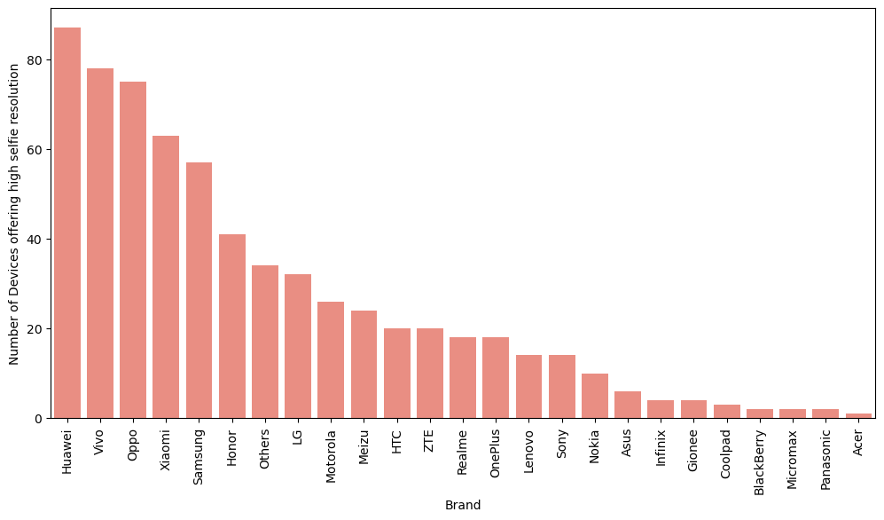

```python
# Check for any missing values in the selfie_camera_mp and brand_name columns
print(df[['selfie_camera_mp', 'brand_name']].isnull().sum())

# Drop rows with missing values in selfie_camera_mp and brand_name columns
df = df.dropna(subset=['selfie_camera_mp', 'brand_name'])

# Filter data for devices with selfie cameras greater than 8MP
high_selfie_camera_df = df[df['selfie_camera_mp'] > 8]

# Count the number of devices per brand with high selfie camera resolution
brand_selfie_camera_count = high_selfie_camera_df['brand_name'].value_counts().reset_index()
brand_selfie_camera_count.columns = ['brand_name', 'count']
print(brand_selfie_camera_count)

# Visualize the distribution of high selfie camera resolution devices across brands using a bar plot
plt.figure(figsize=(12, 6))
sns.barplot(x='brand_name', y='count', data=brand_selfie_camera_count, color='salmon')
plt.xticks(rotation=90)
plt.xlabel('Brand')
plt.ylabel('Number of Devices offering high selfie resolution')
plt.show()
```

- Huawei, Vivo, Oppo, Xiaomi, Samsung and Honor offer a considerable amount of devices with high selfie resolution.

### Which attributes are highly correlated with the normalized price of a used device?

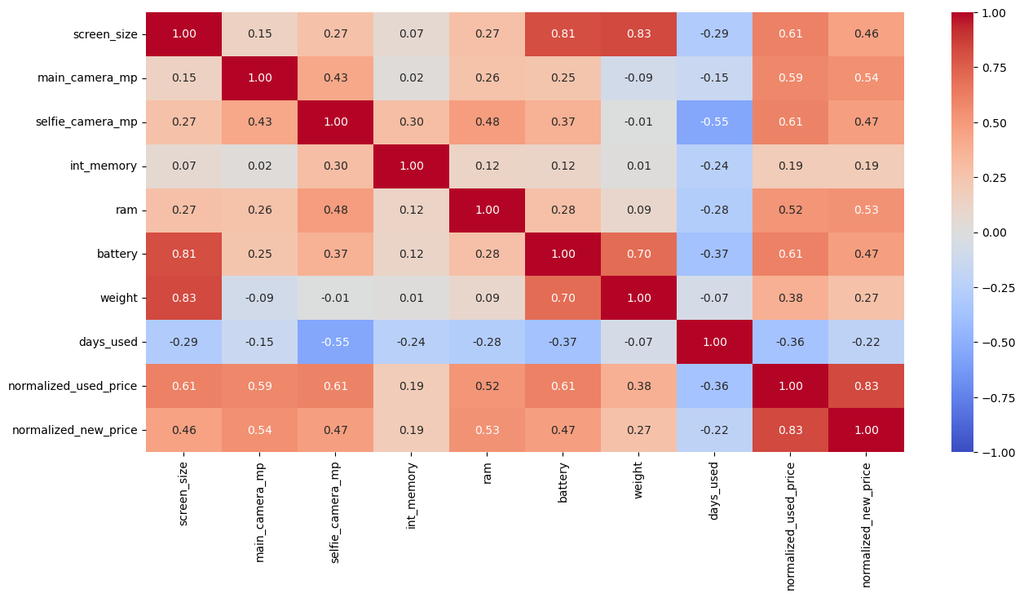

```python
cols_list = df.select_dtypes(include=np.number).columns.tolist()
# dropping release_year as it is a temporal variable
cols_list.remove("release_year")

plt.figure(figsize=(15, 7))
sns.heatmap(
    df[cols_list].corr(), annot=True, vmin=-1, vmax=1, fmt=".2f", cmap="coolwarm"
)
plt.show()
```

- Screen size correlation with normalized used price: 0.61. Larger screen sizes tend to be associated with higher normalized used prices.
- Main camera mp correlation with normalized used price: 0.59. Higher megapixel main cameras are correlated with higher normalized used prices.
- Selfie camera mp correlation with normalized used price: 0.61. Higher megapixel selfie cameras are correlated with higher normalized used prices.
- Battery capacity correlation with normalized used price: 0.61. Larger battery capacities are correlated with higher normalized used prices.

### Check how the prices vary for used phones and tablets offering 4G and 5G networks.

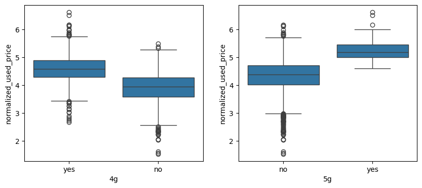

```python
plt.figure(figsize=(10, 4))

plt.subplot(121)
sns.boxplot(data=df, x="4g", y="normalized_used_price")

plt.subplot(122)
sns.boxplot(data=df, x="5g", y="normalized_used_price")

plt.show()
```

- 4G devices tend to have lower prices compared to 5G phones.
- The normalized used prices for 5G devices are ranging between 4 to 6.
- 5G phones are more expensive.

## Data Preprocessing

- Missing value treatment
- Feature engineering (if needed)
- Outlier detection and treatment (if needed)
- Preparing data for modeling
- Any other preprocessing steps (if needed)

### Missing values

```python
#Checking for missing values
missing_values = data.isnull().sum()
print(missing_values)
print('')
it_has_missing_values = data.isnull().sum().any()
print("Are there any missing values: true or false?", it_has_missing_values)
```

```
brand_name                 0
os                         0
screen_size                0
4g                         0
5g                         0
main_camera_mp           179
selfie_camera_mp           2
int_memory                 4
ram                        4
battery                    6
weight                     7
release_year               0
days_used                  0
normalized_used_price      0
normalized_new_price       0
dtype: int64

Are there any missing values: true or false? True
```

```python
df1 = data.copy()
```

```python
cols_impute = [
    # this list contains the names of the columns for which missing values need to be imputed
    "main_camera_mp",
    "selfie_camera_mp",
    "int_memory",
    "ram",
    "battery",
    "weight",
]

for col in cols_impute:
    # method fill na is used to fill missing values
    df1[col] = df1[col].fillna(
        # groups the data frame by release year and brand name
        # transform median calculates the median value for each group
        value=df1.groupby(['release_year', 'brand_name'])[col].transform("median")
    )

# checking for missing values after imputing the above columns
print(df1.isnull().sum())
```

```
brand_name                 0
os                         0
screen_size                0
4g                         0
5g                         0
main_camera_mp           179
selfie_camera_mp           2
int_memory                 0
ram                        0
battery                    6
weight                     7
release_year               0
days_used                  0
normalized_used_price      0
normalized_new_price       0
dtype: int64
```

```python
cols_impute = [
    # this list contains the names of the columns for which missing values need to be imputed
    "main_camera_mp",
    "selfie_camera_mp",
    "battery",
    "weight",
]

for col in cols_impute:
    df1[col] = df1[col].fillna(
        # groups the data frame by  brand name
        value=df1.groupby(['brand_name'])[col].transform("median")
    )

# checking for missing values after imputing the above columns
print(df1.isnull().sum())
```

```
brand_name                0
os                        0
screen_size               0
4g                        0
5g                        0
main_camera_mp           10
selfie_camera_mp          0
int_memory                0
ram                       0
battery                   0
weight                    0
release_year              0
days_used                 0
normalized_used_price     0
normalized_new_price      0
dtype: int64
```

```python
df1["main_camera_mp"] = df1["main_camera_mp"].fillna(df1["main_camera_mp"].median()) # impute main_camera_mp with median

#check missing values after imputing main camera mp
print(df1.isnull().sum())
```

```
brand_name               0
os                       0
screen_size              0
4g                       0
5g                       0
main_camera_mp           0
selfie_camera_mp         0
int_memory               0
ram                      0
battery                  0
weight                   0
release_year             0
days_used                0
normalized_used_price    0
normalized_new_price     0
dtype: int64
```

### Featuring engineering

```python
# creates new feature / 2021 as baseline
df1["years_since_release"] = 2021 - df1["release_year"]
# drop unnecessary feature
df1.drop("release_year", axis=1, inplace=True)
df1["years_since_release"].describe()
```

```
count    3454.000000
mean        5.034742
std         2.298455
min         1.000000
25%         3.000000
50%         5.500000
75%         7.000000
max         8.000000
Name: years_since_release, dtype: float64
```

### Outliers

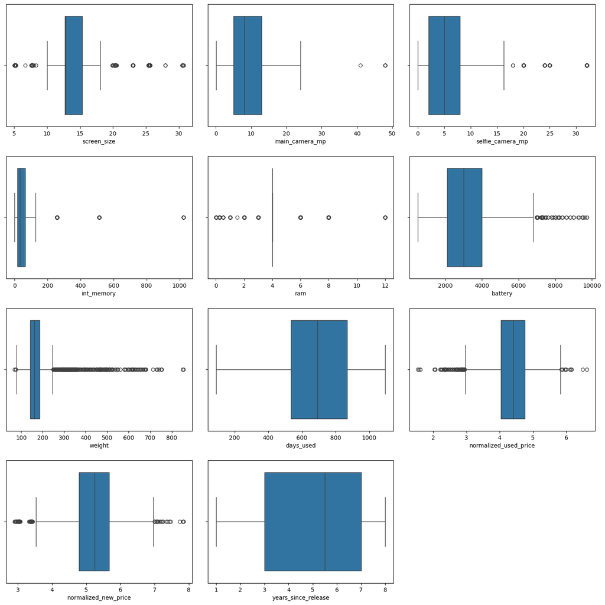

```python
# outlier detection using boxplot
num_cols = df1.select_dtypes(include=np.number).columns.tolist()

plt.figure(figsize=(15, 15))

for i, variable in enumerate(num_cols):
    plt.subplot(4, 3, i + 1)
    sns.boxplot(data=df1, x=variable)
    plt.tight_layout(pad=2)

plt.show()
```

### Data preparation for modelling

### ensure all data is numerical

```python
# Check which datatypes do I have
print(df1.dtypes)
```

```
brand_name                object
os                        object
screen_size              float64
4g                        object
5g                        object
main_camera_mp           float64
selfie_camera_mp         float64
int_memory               float64
ram                      float64
battery                  float64
weight                   float64
days_used                  int64
normalized_used_price    float64
normalized_new_price     float64
years_since_release        int64
dtype: object
```

```python
# to perform one hot encoding specifing categorical data types
# drop first - drops the first category in each one hot encoded column to avoid multicolinearity
df1 = pd.get_dummies(df1, columns=['brand_name', 'os', '4g', '5g'], drop_first=True)
```

```python
# convert boolean columns to integers to ensure compatibility with ML algorithms
boolean_columns = df1.select_dtypes(include=['bool']).columns
df1[boolean_columns] = df1[boolean_columns].astype(int)
```

```python
# verifying data types numerical
print(df1.dtypes)
```

```
screen_size              float64
main_camera_mp           float64
selfie_camera_mp         float64
int_memory               float64
ram                      float64
battery                  float64
weight                   float64
days_used                  int64
normalized_used_price    float64
normalized_new_price     float64
years_since_release        int64
brand_name_Alcatel         int64
brand_name_Apple           int64
brand_name_Asus            int64
brand_name_BlackBerry      int64
brand_name_Celkon          int64
brand_name_Coolpad         int64
brand_name_Gionee          int64
brand_name_Google          int64
brand_name_HTC             int64
brand_name_Honor           int64
brand_name_Huawei          int64
brand_name_Infinix         int64
brand_name_Karbonn         int64
brand_name_LG              int64
brand_name_Lava            int64
brand_name_Lenovo          int64
brand_name_Meizu           int64
brand_name_Micromax        int64
brand_name_Microsoft       int64
brand_name_Motorola        int64
brand_name_Nokia           int64
brand_name_OnePlus         int64
brand_name_Oppo            int64
brand_name_Others          int64
brand_name_Panasonic       int64
brand_name_Realme          int64
brand_name_Samsung         int64
brand_name_Sony            int64
brand_name_Spice           int64
brand_name_Vivo            int64
brand_name_XOLO            int64
brand_name_Xiaomi          int64
brand_name_ZTE             int64
os_Others                  int64
os_Windows                 int64
os_iOS                     int64
4g_yes                     int64
5g_yes                     int64
dtype: object
```

```python
# Define the independent variables (features) and dependent variable (target)
X = df1.drop('normalized_used_price', axis=1)
y = df1['normalized_used_price']

print(X.head())
print(y.head())
```

```
   screen_size  main_camera_mp  selfie_camera_mp  int_memory  ram  battery  \
0        14.50            13.0               5.0        64.0  3.0   3020.0
1        17.30            13.0              16.0       128.0  8.0   4300.0
2        16.69            13.0               8.0       128.0  8.0   4200.0
3        25.50            13.0               8.0        64.0  6.0   7250.0
4        15.32            13.0               8.0        64.0  3.0   5000.0

   weight  days_used  normalized_new_price  years_since_release  ...  \
0   146.0        127              4.715100                    1  ...
1   213.0        325              5.519018                    1  ...
2   213.0        162              5.884631                    1  ...
3   480.0        345              5.630961                    1  ...
4   185.0        293              4.947837                    1  ...

   brand_name_Spice  brand_name_Vivo  brand_name_XOLO  brand_name_Xiaomi  \
```

[output cut: 20 more lines]

```python
# let's add the intercept to data
X = sm.add_constant(X)
```

```python
# splitting the data in 70:30 ratio for train to test data
x_train, x_test, y_train, y_test = train_test_split(X, y, test_size=0.3, random_state=42)
```

```python
print(f"x_train shape: {x_train.shape}")
print(f"x_test shape: {x_test.shape}")
print(f"y_train shape (# rows in train data): {y_train.shape[0]}")
print(f"y_test shape (# rows in test data): {y_test.shape[0]}")
```

```
x_train shape: (2417, 49)
x_test shape: (1037, 49)
y_train shape (# rows in train data): 2417
y_test shape (# rows in test data): 1037
```

```python
print(df1.dtypes)
```

```
screen_size              float64
main_camera_mp           float64
selfie_camera_mp         float64
int_memory               float64
ram                      float64
battery                  float64
weight                   float64
days_used                  int64
normalized_used_price    float64
normalized_new_price     float64
years_since_release        int64
brand_name_Alcatel         int64
brand_name_Apple           int64
brand_name_Asus            int64
brand_name_BlackBerry      int64
brand_name_Celkon          int64
brand_name_Coolpad         int64
brand_name_Gionee          int64
brand_name_Google          int64
brand_name_HTC             int64
brand_name_Honor           int64
brand_name_Huawei          int64
brand_name_Infinix         int64
brand_name_Karbonn         int64
brand_name_LG              int64
brand_name_Lava            int64
brand_name_Lenovo          int64
brand_name_Meizu           int64
brand_name_Micromax        int64
brand_name_Microsoft       int64
brand_name_Motorola        int64
brand_name_Nokia           int64
brand_name_OnePlus         int64
brand_name_Oppo            int64
brand_name_Others          int64
brand_name_Panasonic       int64
brand_name_Realme          int64
brand_name_Samsung         int64
brand_name_Sony            int64
brand_name_Spice           int64
brand_name_Vivo            int64
brand_name_XOLO            int64
brand_name_Xiaomi          int64
brand_name_ZTE             int64
os_Others                  int64
os_Windows                 int64
os_iOS                     int64
4g_yes                     int64
5g_yes                     int64
dtype: object
```

## Model Building - Linear Regression

```python
# Fit the OLS model
olsmodel1 = sm.OLS(y_train, x_train).fit()

#Print the summary of the model
print(olsmodel1.summary())
```

```
                              OLS Regression Results
=================================================================================
Dep. Variable:     normalized_used_price   R-squared:                       0.849
Model:                               OLS   Adj. R-squared:                  0.846
Method:                    Least Squares   F-statistic:                     277.1
Date:                   Fri, 24 Jan 2025   Prob (F-statistic):               0.00
Time:                           19:15:12   Log-Likelihood:                 125.15
No. Observations:                   2417   AIC:                            -152.3
Df Residuals:                       2368   BIC:                             131.4
Df Model:                             48
Covariance Type:               nonrobust
=========================================================================================
                            coef    std err          t      P>|t|      [0.025      0.975]
-----------------------------------------------------------------------------------------
const                     1.4172      0.072     19.677      0.000       1.276       1.558
screen_size               0.0295      0.004      8.352      0.000       0.023       0.036
main_camera_mp            0.0232      0.002     14.892      0.000       0.020       0.026
selfie_camera_mp          0.0116      0.001      9.924      0.000       0.009       0.014
int_memory                0.0002   6.76e-05      2.779      0.005    5.53e-05       0.000
ram                       0.0305      0.005      5.797      0.000       0.020       0.041
battery               -1.665e-05   7.35e-06     -2.266      0.024   -3.11e-05   -2.24e-06
weight                    0.0008      0.000      5.946      0.000       0.001       0.001
days_used              3.376e-05   3.07e-05      1.101      0.271   -2.64e-05    9.39e-05
normalized_new_price      0.4104      0.012     33.494      0.000       0.386       0.434
years_since_release      -0.0255      0.005     -5.589      0.000      -0.034      -0.017
brand_name_Alcatel       -0.0804      0.050     -1.618      0.106      -0.178       0.017
brand_name_Apple         -0.0438      0.148     -0.297      0.767      -0.333       0.246
brand_name_Asus           0.0068      0.049      0.138      0.890      -0.090       0.103
brand_name_BlackBerry     0.0312      0.072      0.434      0.664      -0.110       0.172
brand_name_Celkon        -0.2372      0.068     -3.485      0.001      -0.371      -0.104
brand_name_Coolpad       -0.0308      0.071     -0.434      0.664      -0.170       0.108
brand_name_Gionee        -0.0130      0.059     -0.221      0.825      -0.128       0.102
brand_name_Google        -0.1192      0.083     -1.442      0.149      -0.281       0.043
brand_name_HTC           -0.0403      0.050     -0.805      0.421      -0.138       0.058
brand_name_Honor         -0.0478      0.051     -0.941      0.347      -0.147       0.052
brand_name_Huawei        -0.0599      0.046     -1.299      0.194      -0.150       0.030
brand_name_Infinix        0.1338      0.113      1.179      0.238      -0.089       0.356
brand_name_Karbonn       -0.0592      0.068     -0.867      0.386      -0.193       0.075
brand_name_LG            -0.0608      0.047     -1.299      0.194      -0.152       0.031
brand_name_Lava          -0.0230      0.063     -0.364      0.716      -0.147       0.101
```

[output cut: 19 more lines]

```
os_Windows               -0.0374      0.043     -0.861      0.389      -0.122       0.048
os_iOS                   -0.0141      0.148     -0.095      0.924      -0.304       0.276
4g_yes                    0.0406      0.016      2.514      0.012       0.009       0.072
5g_yes                   -0.0916      0.032     -2.846      0.004      -0.155      -0.029
==============================================================================
Omnibus:                      234.465   Durbin-Watson:                   1.994
Prob(Omnibus):                  0.000   Jarque-Bera (JB):              630.705
Skew:                          -0.536   Prob(JB):                    1.11e-137
Kurtosis:                       5.262   Cond. No.                     1.85e+05
==============================================================================

Notes:
[1] Standard Errors assume that the covariance matrix of the errors is correctly specified.
[2] The condition number is large, 1.85e+05. This might indicate that there are
strong multicollinearity or other numerical problems.
```

## Model Performance Check

```python
# Define MAPE (Mean Absolute Percentage Error)
def mean_absolute_percentage_error(y_true, y_pred):
    return np.mean(np.abs((y_true - y_pred) / y_true)) * 100

# Define adjusted R^2
def adjusted_r2_score(r2, n, k):
    return 1 - (1 - r2) * (n - 1) / (n - k - 1)

# Define a function to print all metrics
def print_metrics(y_true, y_pred, n, k):
    mse = mean_squared_error(y_true, y_pred)
    print("Mean squared error:", mse)
    rmse = np.sqrt(mse)
    print("RMSE:", rmse)
    mae = mean_absolute_error(y_true, y_pred)
    print("MAE:", mae)
    r2 = r2_score(y_true, y_pred)
    print("R2:", r2)
    adj_r2 = adjusted_r2_score(r2, n, k)
    print("Adjusted R2:", adj_r2)
    mape = mean_absolute_percentage_error(y_true, y_pred)
    print("MAPE:", mape)
```

```python
# Make predictions on the training set
y_train_pred = olsmodel1.predict(x_train)

# Make predictions on the test set
y_test_pred = olsmodel1.predict(x_test)

# Number of observations and number of features (excluding the intercept)
n_train = x_train.shape[0]
n_test = x_test.shape[0]
k = x_train.shape[1] - 1

print("Model performance on the training set: seen 70% data")
print("")
print_metrics(y_train, y_train_pred, n_train, k)
print("\nModel performance on the test set: seen 30% data")
print("")
print_metrics(y_test, y_test_pred, n_test, k)
```

```
Model performance on the training set: seen 70% data

Mean squared error: 0.052789978891813846
RMSE: 0.22976069918899064
MAE: 0.1785331303559496
R2: 0.8488865470544611
Adjusted R2: 0.8458234365217813
MAPE: 4.293664452185178

Model performance on the test set: seen 30% data

Mean squared error: 0.05715049913984248
RMSE: 0.2390617057159981
MAE: 0.18869212876194727
R2: 0.8321757391826731
Adjusted R2: 0.8240223337988353
MAPE: 4.513287766034246
```

### Model Performance on the Training Set (70% of data):

- *Mean Squared Error (MSE)*: 0.0528
- *Root Mean Squared Error (RMSE)*: 0.2298
- *Mean Absolute Error (MAE)*: 0.1785
- *Mean Absolute Percentage Error (MAPE)*: 4.29%
- *R-squared (R2)*: 0.8489
- *Adjusted R-squared*: 0.8458

### Model Performance on the Test Set (30% of data):

- *Mean Squared Error (MSE)*: 0.0572
- *Root Mean Squared Error (RMSE)*: 0.2391
- *Mean Absolute Error (MAE)*: 0.1887
- *Mean Absolute Percentage Error (MAPE)*: 4.51%
- *R-squared (R2)*: 0.8322
- *Adjusted R-squared*: 0.8240

### Analysis:

1. Performance:

- The error metrics (MSE, RMSE, MAE, and MAPE) are a bit higher on the test set compared to the training set.
- This behaviour is expected because the model generally performs better on the data it has seen during training.
- The increase in error metrics from training to test set is not high hence the model generalize well with unseen data.

2. R-squared and Adjusted R-squared:

- The R-squared values are high for both the training set (0.8489) and the test set (0.8322), indicating that the model explains a significant portion of the variance in the target variable.
- The Adjusted R-squared values are also high and close to the R-squared values, suggesting that the model is not overfitting and that the predictors are relevant.

3. Error Metrics:

- The RMSE values (0.2298 for training and 0.2391 for testing) are small, so we can evidence that the model’s predictions align with the actual values.
- The MAE values (0.1785 for training and 0.1887 for testing) are also low, suggesting that the model’s average prediction error is minimal.
- The MAPE values (4.29% for training and 4.51% for testing) suggest that the average percentage error in predictions is small and the model performs accurately on both the training and testing datasets.
- The model generalizes well to unseen data with only a slight increase in error metrics on the test set.
- The high R-squared values and low error metrics indicate that the model is making accurate predictions.
- Overall, the model is behaving well and demonstrates strong predictive performance.

## Checking Linear Regression Assumptions

### MULTICOLINEARITY

Test for multicollinearity using VIF.

General Rule of thumb:

- If VIF is 1 then there is no correlation between the th predictor and the remaining predictor variables.
- If VIF exceeds 5 or is close to exceeding 5, we say there is moderate multicollinearity.
- If VIF is 10 or exceeding 10, it shows signs of high multicollinearity.

```python
# Define the function to calculate VIF
def calculate_vif(predictors):
    vif = pd.DataFrame()
    vif["feature"] = predictors.columns

    # calculating VIF for each feature
    vif["VIF"] = [
        variance_inflation_factor(predictors.values, i)
        for i in range(len(predictors.columns))
    ]
    return vif
```

```python
# Check VIF on train data
vif_data = calculate_vif(x_train)
print("VIF before treating multicollinearity:\n", vif_data)
```

```
VIF before treating multicollinearity:
                   feature         VIF
0                   const  232.676933
1             screen_size    8.262147
2          main_camera_mp    2.418167
3        selfie_camera_mp    2.872720
4              int_memory    1.363390
5                     ram    2.283507
6                 battery    4.066126
7                  weight    6.417982
8               days_used    2.580338
9    normalized_new_price    3.218722
10    years_since_release    4.878548
11     brand_name_Alcatel    3.458576
12       brand_name_Apple   11.195090
```

[output cut: 36 more lines]

```python
def treating_multicollinearity(predictors, target, high_vif_columns):
    """
    Checking the effect of dropping the columns showing high multicollinearity
    on model performance (adj. R-squared and RMSE)

    predictors: independent variables
    target: dependent variable
    high_vif_columns: columns having high VIF
    """
    results = []

    for col in high_vif_columns:
        # Defining the new train set
        train = predictors.drop(columns=[col])

        # Create the model
        olsmodel = sm.OLS(target, train).fit()

        # Store the adjusted R-squared and RMSE
        results.append({
            "col": col,
            "Adj. R-squared after dropping col": olsmodel.rsquared_adj,
            "RMSE after dropping col": np.sqrt(olsmodel.mse_resid)
        })

    # Create a DataFrame for the results
    results_df = pd.DataFrame(results).sort_values(by="Adj. R-squared after dropping col", ascending=False)
    results_df.reset_index(drop=True, inplace=True)

    return results_df
```

```python
# Specify the columns with high VIF (e.g., VIF > 5)
high_vif_columns = vif_data[vif_data['VIF'] > 5]['feature'].tolist()

# Check the effect on model performance after dropping specified columns from train data
res = treating_multicollinearity(x_train, y_train, high_vif_columns)
print("Effect on model performance after dropping columns with high VIF:\n", res)

# Assuming 'res' contains the results from treating_multicollinearity function
# Specify the column to drop (the one with the highest adjusted R-squared after dropping)
col_to_drop = res.iloc[0]['col']

# Update the train data by dropping the specified column
x_train2 = x_train.drop(columns=[col_to_drop])

# Update the test data by dropping the specified column
x_test2 = x_test.drop(columns=[col_to_drop])

# Check VIF now
vif = calculate_vif(x_train2)
print("VIF after dropping ", col_to_drop, ":\n", vif)
```

```
Effect on model performance after dropping columns with high VIF:
                   col  Adj. R-squared after dropping col  \
0               const                           0.996765
1              os_iOS                           0.845888
2    brand_name_Apple                           0.845883
3   brand_name_Huawei                           0.845779
4       brand_name_LG                           0.845779
5  brand_name_Samsung                           0.845765
6   brand_name_Others                           0.845731
7              weight                           0.843587
8         screen_size                           0.841348

   RMSE after dropping col
0                 0.250332
1                 0.232077
```

[output cut: 57 more lines]

```python
# Initial list of columns
initial_predictors = x_train.copy()  # Copy the training dataset to check for p-values
column_list = initial_predictors.columns.tolist()  # Get the list of columns

# Setting an initial maximum p-value
threshold_p_value = 0.05

while len(column_list) > 0:
    # Defining the train set with the current list of columns
    x_train_subset = initial_predictors[column_list]

    # Fitting the model
    interim_model = sm.OLS(y_train, x_train_subset).fit()

    # Getting the p-values and the maximum p-value
    interim_p_values = interim_model.pvalues
    current_max_p_value = interim_p_values.max()

    # Identifying the variable with the maximum p-value
    feature_with_highest_p_value = interim_p_values.idxmax()

    if current_max_p_value > threshold_p_value:
        print(f"Dropping {feature_with_highest_p_value} with p-value {current_max_p_value}")
        column_list.remove(feature_with_highest_p_value)
    else:
        break

final_selected_features = column_list
print("Final selected features:", final_selected_features)

# Assuming 'final_selected_features' contains the final set of features after removing high p-values
x_train_3 = x_train[final_selected_features]  # Select the specified columns from the train data
x_test_3 = x_test[final_selected_features]  # Select the specified columns from the test data

# Refit the OLS model with the final selected features
ols_model_3 = sm.OLS(y_train, x_train_3).fit()
print(ols_model_3.summary())
```

```
Dropping os_iOS with p-value 0.9240870468746296
Dropping brand_name_Asus with p-value 0.8900811309274699
Dropping brand_name_Gionee with p-value 0.697416393192043
Dropping brand_name_Lava with p-value 0.6416867673089856
Dropping brand_name_Coolpad with p-value 0.6328562540330571
Dropping brand_name_Spice with p-value 0.5999394939016132
Dropping brand_name_OnePlus with p-value 0.6091303256115852
Dropping brand_name_Realme with p-value 0.5984677627174554
Dropping brand_name_Oppo with p-value 0.5752939551721958
Dropping brand_name_Panasonic with p-value 0.5818300120873456
Dropping brand_name_Lenovo with p-value 0.46809834802383654
Dropping brand_name_HTC with p-value 0.5451082926991282
Dropping brand_name_Karbonn with p-value 0.5396621935020511
Dropping brand_name_Apple with p-value 0.4881563822961773
Dropping brand_name_Honor with p-value 0.5005167854895806
Dropping brand_name_ZTE with p-value 0.5220387185886038
Dropping os_Windows with p-value 0.39047852349260137
Dropping brand_name_BlackBerry with p-value 0.2818214019221046
Dropping days_used with p-value 0.23701179073109513
Dropping brand_name_XOLO with p-value 0.2272131158963378
Dropping brand_name_Micromax with p-value 0.2631958979636272
Dropping brand_name_Vivo with p-value 0.2641084232694289
Dropping brand_name_Motorola with p-value 0.24809984273335794
Dropping brand_name_Huawei with p-value 0.2833834143746962
Dropping brand_name_LG with p-value 0.340638205558047
Dropping brand_name_Sony with p-value 0.3092281061888526
Dropping brand_name_Meizu with p-value 0.3124886612471559
Dropping brand_name_Samsung with p-value 0.3182411653373488
Dropping brand_name_Google with p-value 0.31997353270331413
Dropping brand_name_Alcatel with p-value 0.25695387489059884
Dropping brand_name_Others with p-value 0.20374123409950837
Dropping brand_name_Microsoft with p-value 0.09796756192092658
Dropping brand_name_Infinix with p-value 0.07962759512057828
Final selected features: ['const', 'screen_size', 'main_camera_mp', 'selfie_camera_mp', 'int_memory', 'ram', 'battery', 'weight', 'normalized_new_price', 'years_since_release', 'brand_name_Celkon', 'brand_name_Nokia', 'brand_name_Xiaomi', 'os_Others', '4g_yes', '5g_yes']
                              OLS Regression Results
=================================================================================
Dep. Variable:     normalized_used_price   R-squared:                       0.847
Model:                               OLS   Adj. R-squared:                  0.846
Method:                    Least Squares   F-statistic:                     886.8
Date:                   Fri, 24 Jan 2025   Prob (F-statistic):               0.00
```

[output cut: 20 more lines]

```
brand_name_Xiaomi        0.0829      0.025      3.296      0.001       0.034       0.132
os_Others               -0.0598      0.030     -1.993      0.046      -0.119      -0.001
4g_yes                   0.0461      0.015      3.023      0.003       0.016       0.076
5g_yes                  -0.0900      0.031     -2.862      0.004      -0.152      -0.028
==============================================================================
Omnibus:                      240.704   Durbin-Watson:                   1.993
Prob(Omnibus):                  0.000   Jarque-Bera (JB):              674.212
Skew:                          -0.537   Prob(JB):                    3.95e-147
Kurtosis:                       5.354   Cond. No.                     4.08e+04
==============================================================================

Notes:
[1] Standard Errors assume that the covariance matrix of the errors is correctly specified.
[2] The condition number is large, 4.08e+04. This might indicate that there are
strong multicollinearity or other numerical problems.
```

```python
# Make predictions on the training set
y_train_pred3 = ols_model_3.predict(x_train_3)

# Make predictions on the test set
y_test_pred3 = ols_model_3.predict(x_test_3)

# Number of observations and number of features (excluding the intercept)
n_train = x_train_3.shape[0]
n_test = x_test_3.shape[0]
k = x_train_3.shape[1] - 1

print("Model performance on the training set: seen 70% data")
print("")
print_metrics(y_train, y_train_pred3, n_train, k)
print("\nModel performance on the test set: seen 30% data")
print("")
print_metrics(y_test, y_test_pred3, n_test, k)
```

```
Model performance on the training set: seen 70% data

Mean squared error: 0.053413464155989264
RMSE: 0.23111353088036465
MAE: 0.1795325337467643
R2: 0.8471017952301935
Adjusted R2: 0.8461465794569544
MAPE: 4.322086820518554

Model performance on the test set: seen 30% data

Mean squared error: 0.05675112276016596
RMSE: 0.23822494151571527
MAE: 0.18870272879235894
R2: 0.8333485206406811
Adjusted R2: 0.830900163940985
MAPE: 4.513062171719157
```

### INDEPENDENCE

- Test for linearity and independence by making a plot of fitted values vs residuals and checking for patterns.

```
        Actual  Predicted  Residuals
1744  4.261975   4.311553  -0.049578
3141  4.175156   3.860832   0.314324
1233  4.117410   4.433246  -0.315836
3046  3.782597   3.848331  -0.065733
2649  3.981922   3.920911   0.061011
```

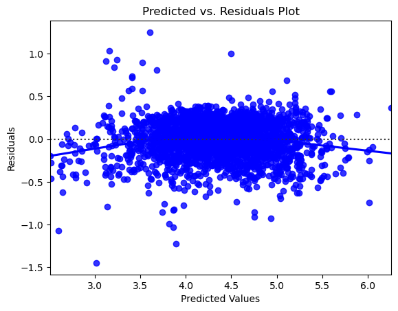

```python
# Create a DataFrame to store actual, fitted, and residual values
results_df = pd.DataFrame()

# Assign actual, fitted, and residual values to the DataFrame
results_df["Actual"] = y_train  # Actual values
results_df["Predicted"] = ols_model_3.fittedvalues  # Predicted (fitted) values
results_df["Residuals"] = ols_model_3.resid  # Residuals

# Display the first few rows of the DataFrame
print(results_df.head())

# Plot the predicted values vs. residuals
sns.residplot(
    data=results_df, x="Predicted", y="Residuals", color="blue", lowess=True
)
plt.xlabel("Predicted Values")
plt.ylabel("Residuals")
plt.title("Predicted vs. Residuals Plot")
plt.show()
```

- The residuals are scattered around the horizontal axis without any clear pattern indicating that the model is linear.
- The residuals are not showing any clustering suggesting independence.

### NORMALITY

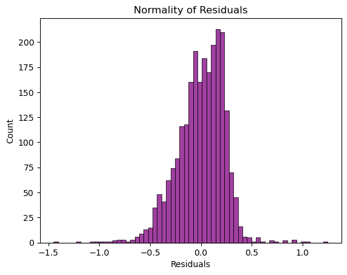

```python
# 'results_df' contains the residuals
# Plot the distribution of residuals
sns.histplot(data=results_df, x='Residuals', color='purple')
plt.title("Normality of Residuals")
plt.show()
```

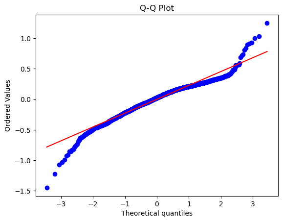

```python
import scipy.stats as stats
import pylab

# Check the Q-Q plot
stats.probplot(results_df['Residuals'], dist="norm", plot=pylab)
plt.title("Q-Q Plot")
plt.show()
```

```python
# Apply the Shapiro-Wilk test
shapiro_test_stat, shapiro_p_value = stats.shapiro(results_df['Residuals'])
print(f"Shapiro-Wilk Test Statistic: {shapiro_test_stat}, p-value: {shapiro_p_value}")
```

```
Shapiro-Wilk Test Statistic: 0.9634817113322149, p-value: 2.9912293496499315e-24
```

### HOMOSCEDASTICITY

- Homoscedasticity means that the residuals have constant variance across all levels of the predicted values. If the residuals are randomly scattered around zero with a constant spread, it indicates homoscedasticity. If there is a pattern (e.g., funnel shape), it indicates heteroscedasticity.

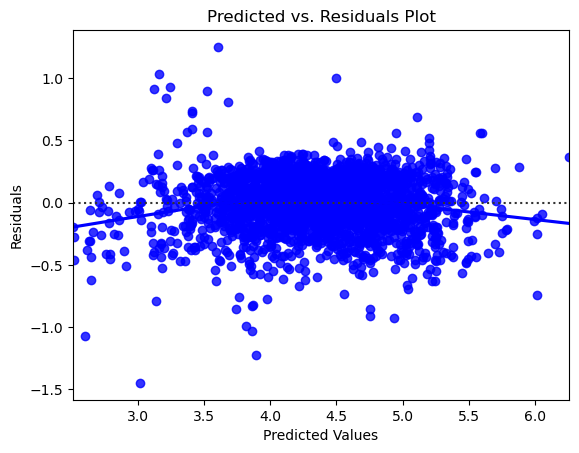

```python
# Plot the predicted values vs. residuals
sns.residplot(
    data=results_df, x="Predicted", y="Residuals", color="blue", lowess=True
)
plt.xlabel("Predicted Values")
plt.ylabel("Residuals")
plt.title("Predicted vs. Residuals Plot")
plt.show()
```

- The residuals are scaterred around the horizontal axis, around zero without any clear pattern indicating homoscedasticity.
- Assupmtion of homoscedasticity is satified in the model.

## Final Model

```python
# Fit the final OLS model
olsmodel_final = sm.OLS(y_train, x_train_3).fit()

# Print the summary of the final model
print(olsmodel_final.summary())
```

```
                              OLS Regression Results
=================================================================================
Dep. Variable:     normalized_used_price   R-squared:                       0.847
Model:                               OLS   Adj. R-squared:                  0.846
Method:                    Least Squares   F-statistic:                     886.8
Date:                   Fri, 24 Jan 2025   Prob (F-statistic):               0.00
Time:                           19:26:37   Log-Likelihood:                 110.96
No. Observations:                   2417   AIC:                            -189.9
Df Residuals:                       2401   BIC:                            -97.27
Df Model:                             15
Covariance Type:               nonrobust
========================================================================================
                           coef    std err          t      P>|t|      [0.025      0.975]
----------------------------------------------------------------------------------------
const                    1.3715      0.052     26.565      0.000       1.270       1.473
screen_size              0.0291      0.003      8.473      0.000       0.022       0.036
main_camera_mp           0.0234      0.001     16.151      0.000       0.021       0.026
selfie_camera_mp         0.0119      0.001     10.644      0.000       0.010       0.014
int_memory               0.0002   6.66e-05      2.836      0.005    5.83e-05       0.000
ram                      0.0293      0.005      5.686      0.000       0.019       0.039
battery               -1.46e-05   7.19e-06     -2.030      0.043   -2.87e-05   -4.94e-07
weight                   0.0008      0.000      6.200      0.000       0.001       0.001
normalized_new_price     0.4092      0.011     36.760      0.000       0.387       0.431
years_since_release     -0.0218      0.004     -5.847      0.000      -0.029      -0.014
brand_name_Celkon       -0.1905      0.053     -3.571      0.000      -0.295      -0.086
brand_name_Nokia         0.0823      0.030      2.771      0.006       0.024       0.140
brand_name_Xiaomi        0.0829      0.025      3.296      0.001       0.034       0.132
os_Others               -0.0598      0.030     -1.993      0.046      -0.119      -0.001
4g_yes                   0.0461      0.015      3.023      0.003       0.016       0.076
5g_yes                  -0.0900      0.031     -2.862      0.004      -0.152      -0.028
==============================================================================
Omnibus:                      240.704   Durbin-Watson:                   1.993
Prob(Omnibus):                  0.000   Jarque-Bera (JB):              674.212
Skew:                          -0.537   Prob(JB):                    3.95e-147
Kurtosis:                       5.354   Cond. No.                     4.08e+04
==============================================================================

Notes:
[1] Standard Errors assume that the covariance matrix of the errors is correctly specified.
[2] The condition number is large, 4.08e+04. This might indicate that there are
strong multicollinearity or other numerical problems.
```

```python
# Make predictions on the training set
y_train_pred3 = olsmodel_final.predict(x_train_3)

# Make predictions on the test set
y_test_pred3 = olsmodel_final.predict(x_test_3)

# Number of observations and number of features (excluding the intercept)
n_train = x_train_3.shape[0]
n_test = x_test_3.shape[0]
k = x_train_3.shape[1] - 1

print("Final Model performance on the training set: seen 70% data")
print("")
print_metrics(y_train, y_train_pred3, n_train, k)
print("\n Final Model performance on the test set: seen 30% data")
print("")
print_metrics(y_test, y_test_pred3, n_test, k)
```

```
Final Model performance on the training set: seen 70% data

Mean squared error: 0.053413464155989264
RMSE: 0.23111353088036465
MAE: 0.1795325337467643
R2: 0.8471017952301935
Adjusted R2: 0.8461465794569544
MAPE: 4.322086820518554

 Final Model performance on the test set: seen 30% data

Mean squared error: 0.05675112276016596
RMSE: 0.23822494151571527
MAE: 0.18870272879235894
R2: 0.8333485206406811
Adjusted R2: 0.830900163940985
MAPE: 4.513062171719157
```

## Actionable Insights and Recommendations

## Insights of model done

### First Model Performance:

*Training Set (70% of data):*

- Mean Squared Error (MSE): 0.052789978891813846
- Root Mean Squared Error (RMSE): 0.22976069918899064
- Mean Absolute Error (MAE): 0.1785331303559496
- R-squared (R2): 0.8488865470544611
- Adjusted R-squared: 0.8458234365217813
- Mean Absolute Percentage Error (MAPE): 4.293664452185178

*Test Set (30% of data):*

- Mean Squared Error (MSE): 0.05715049913984248
- Root Mean Squared Error (RMSE): 0.2390617057159981
- Mean Absolute Error (MAE): 0.18869212876194727
- R-squared (R2): 0.8321757391826731
- Adjusted R-squared: 0.8240223337988353
- Mean Absolute Percentage Error (MAPE): 4.513287766034246

### Final Model Performance:

*Training Set (70% of data):*

- Mean Squared Error (MSE): 0.053413464155989264
- Root Mean Squared Error (RMSE): 0.23111353088036465
- Mean Absolute Error (MAE): 0.1795325337467643
- R-squared (R2): 0.8471017952301935
- Adjusted R-squared: 0.8461465794569544
- Mean Absolute Percentage Error (MAPE): 4.322086820518554

*Test Set (30% of data):*

- Mean Squared Error (MSE): 0.05675112276016596
- Root Mean Squared Error (RMSE): 0.23822494151571527
- Mean Absolute Error (MAE): 0.18870272879235894
- R-squared (R2): 0.8333485206406811
- Adjusted R-squared: 0.830900163940985
- Mean Absolute Percentage Error (MAPE): 4.513062171719157

### Comparison:

1. *Mean Squared Error (MSE)*:

- First Model: Training MSE = 0.0528, Test MSE = 0.0572
- Final Model: Training MSE = 0.0534, Test MSE = 0.0568
- The final model has a slightly higher MSE on the training set but a slightly lower MSE on the test set.

2. *Root Mean Squared Error (RMSE)*:

- First Model: Training RMSE = 0.2298, Test RMSE = 0.2391
- Final Model: Training RMSE = 0.2311, Test RMSE = 0.2382
- The final model has a slightly higher RMSE on the training set but a slightly lower RMSE on the test set.

3. *Mean Absolute Error (MAE)*:

- First Model: Training MAE = 0.1785, Test MAE = 0.1887
- Final Model: Training MAE = 0.1795, Test MAE = 0.1887
- The final model has a slightly higher MAE on the training set and the same MAE on the test set.
4. *Mean Absolute Percentage Error (MAPE)*:
   - First Model: Training MAPE = 4.29%, Test MAPE = 4.51%
   - Final Model: Training MAPE = 4.32%, Test MAPE = 4.51%
   - The first model has a slightly lower MAPE on the training set, but both models have the same MAPE on the test set.

5. *R-squared (R2)*:

- First Model: Training R2 = 0.8489, Test R2 = 0.8322
- Final Model: Training R2 = 0.8471, Test R2 = 0.8333
- The first model has a slightly higher R2 on the training set, but the final model has a slightly higher R2 on the test set.

6. *Adjusted R-squared*:

- First Model: Training Adjusted R2 = 0.8458, Test Adjusted R2 = 0.8240
- Final Model: Training Adjusted R2 = 0.8461, Test Adjusted R2 = 0.8309
- The final model has a slightly higher Adjusted R2 on both the training and test sets.

### Analysis:

The final model shows a slight improvement in some metrics:

- On the test set has lower MSE and RMSE and a higher R2 and Adjusted R2.

However, the differences between the two models are minimal. Both models perform similarly, with the final model having slight better performance in generalization to the test set.

In general, the final model can be considered slighly better than the first model due to its slightly better performance on the test set.

### Conclusions:

1. Highly Correlated Attributes: The heatmap and correlation matrix indicate that the following attributes are highly correlated with the normalized price of a used device:
   - Screen Size: Correlation of 0.61
   - Main Camera MP: Correlation of 0.59
   - Selfie Camera MP: Correlation of 0.61
   - RAM: Correlation of 0.52
   - Battery Capacity: Correlation of 0.61
   - Normalized New Price: Correlation of 0.70
- These attributes are significant predictors of the normalized used price and should be included in the model.
2. The final model demonstrates good predictive performance with high R-squared values and low error metrics.
3. The "Predicted vs. Residuals Plot" shows that the residuals are randomly scattered around the horizontal axis without any clear pattern, indicating that the model is linear and the residuals are independent.
4. The histogram and Q-Q plot of residuals suggest that the residuals are approximately normally distributed, although the Shapiro-Wilk test indicates that the residuals are not perfectly normal (p-value < 0.05)
5. The "Predicted vs. Residuals Plot" suggests that the residuals have a constant variance across all levels of the predicted values, indicating homoscedasticity
6. The linear regression model developed for predicting the price of used phones is good and performs well. The models explains the variance in the normalized used price and key attributes influencing the price have been identified, the key attributes are the ones mentioned in point #1.
7. I recommend to deploy the model to predict the prices of used refurbished devices, this way ReCell can develop a dynamic pricing strategy.
8. It is recommended as well to update the model with the new data to always ensure efficiency and accuracy in the dynamic market.